# Predicting Prices of Airbnbs Using ML

Venkat Somala

## Part 0: Overview and Objectives

The ultimate goal of our analysis will be to build a predictive model of price and to understand the listing features with which this might be associated.

Specifically:

How accurately can we predict the price of an Airbnb listing by its features? Not only might this information help Airbnb, it might help new listers with guidance on how much they might charge.

What makes some listings more expensive than others?!

Airbnb has publicly available data on its listings. We’ll focus on Airbnb listings in New York City. To this end, you can find data on nearly 45,000 listings.

## Part 1: Ready the data

```r
library(ggplot2)
library(dplyr)
library(caret)
library(ggridges)
```

```r
airbnb <- read.csv("NYC_airbnb_kaggle_copy.csv")
NYC_nbd <- read.csv("NYC_nbhd_kaggle_copy.csv")
```

```r
#head(airbnb)
#head(NYC_nbd)
dim(airbnb)
```

```
## [1] 44317    31
```

```r
dim(NYC_nbd)
```

```
## [1] 230   2
```

```r
airbnb_new <- left_join(airbnb, NYC_nbd, by = c("neighbourhood_cleansed"="neighbourhood"))
impute_info <- airbnb_new %>%
  preProcess(method = "knnImpute")
airbnb_new <- predict(impute_info, newdata = airbnb_new)
sum(complete.cases(airbnb_new))
```

```
## [1] 44317
```

```r
#head(airbnb_new, 2)
```

```r
airbnb_slim <- airbnb_new %>%
  select(-c(id, latitude, longitude, is_location_exact, neighbourhood_cleansed, amenities)) %>%
  filter(price < 1000) %>%
  sample_n(5000)

dim(airbnb_slim)
```

```
## [1] 5000   26
```

```r
head(airbnb_slim, 2)
```

```
##   host_response_time host_response_rate host_is_superhost
## 1                N/A                N/A                 f
## 2     within an hour                90%                 f
##   host_has_profile_pic property_type       room_type accommodates
## 1                    t     Apartment    Private room   -0.4388584
## 2                    t     Apartment Entire home/apt   -0.4388584
##    bathrooms bedrooms       beds bed_type square_feet      price
## 1 -0.3220221 -0.22034 -0.5186317 Real Bed  -0.8807408 -0.4192236
## 2 -0.3220221 -0.22034 -0.5186317 Real Bed  -0.5333286  0.4844821
##   guests_included minimum_nights maximum_nights calendar_updated
## 1      -0.4423159     0.07883499   -0.006119401    14 months ago
## 2      -0.4423159     0.47645527   -0.006117400      2 weeks ago
##   availability_30 number_of_reviews review_scores_rating instant_bookable
## 1      -0.6489067        -0.4277980          -0.05938067                f
## 2      -0.6489067        -0.5185239           0.79327893                f
##   is_business_travel_ready cancellation_policy
## 1                        f            moderate
## 2                        f            flexible
##   require_guest_profile_picture reviews_per_month neighbourhood_group
## 1                             f        -0.7239659           Manhattan
## 2                             f        -0.2723903           Manhattan
```

We took out variables that were not relevant to predict the price. We did not think that ID, latitude, longitude, the exact location categoriacal, or amenities were important in determing price. We believe that taking these variables out could have also potentionally saved the model form homogeneity. We believe that taking these variables out will allow us to have a clearer data set.

## Part 2: Analyze

We used KNN-model and lasso-model to predict the price from 25 predictors in the dataset.

We dealt with the missing data by imputing the original data. This may lead to an overly optimistic modeling. Some missing data are missing as N/A, which may be identified as a separate variable during the modeling process.

```r
lambda_grid <- 10^seq(-3, 1, length = 100)
set.seed(253)
lassoairbnb <- train(
  price ~ .,
  data = airbnb_slim,
  method = "glmnet",
  trControl = trainControl(method = "cv", number = 10, selectionFunction = "oneSE"),
  tuneGrid = data.frame(alpha = 1, lambda = lambda_grid),
  metric = "MAE",
  na.action = na.omit
)
```

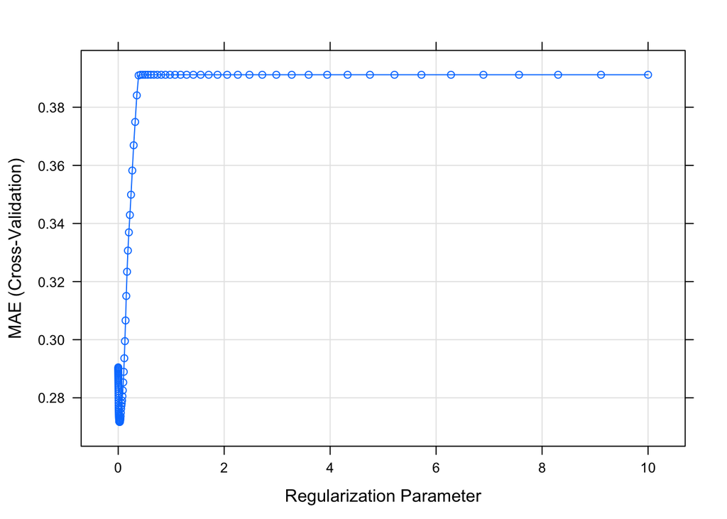

```r
plot(lassoairbnb)
```

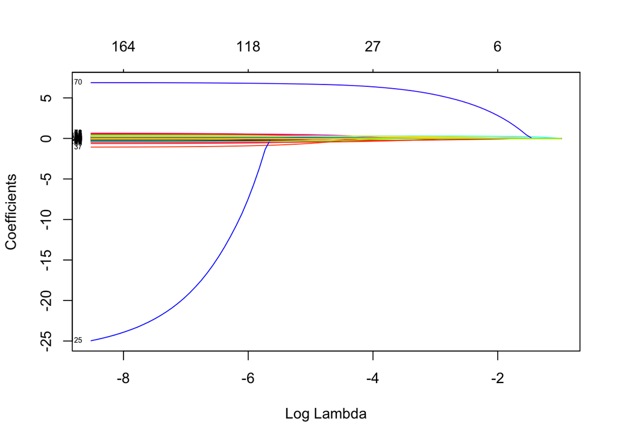

```r
plot(lassoairbnb$finalModel, xvar = "lambda", label = TRUE, col = rainbow(20))
```

```r
lassoairbnb$results %>% filter (lambda == lassoairbnb$bestTune$lambda )
```

```
##   alpha     lambda     RMSE  Rsquared       MAE    RMSESD RsquaredSD
## 1     1 0.05462277 0.631103 0.3809836 0.2762339 0.2075848  0.1010985
##        MAESD
## 1 0.01384297
```

```r
model_coef <- coef(lassoairbnb$finalModel, lassoairbnb$bestTune$lambda)
predictors <- model_coef@Dimnames[[1]][model_coef@i + 1][-1]
```

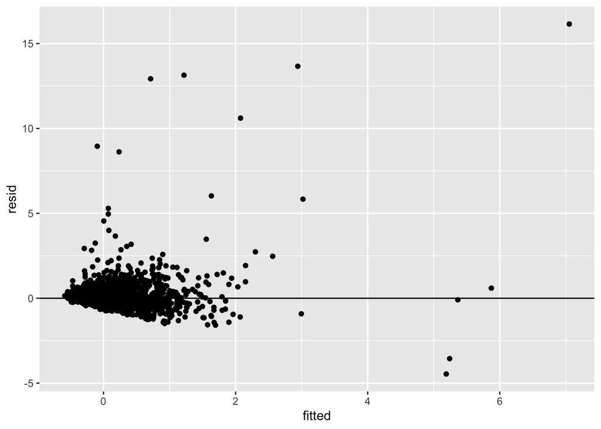

```r
result_df <- data.frame(resid = resid(lassoairbnb), fitted = fitted(lassoairbnb))
# Residual plot
ggplot(result_df, aes(x = fitted, y = resid)) +
  geom_point() +
  geom_hline(yintercept = 0)
```

```r
coef(lassoairbnb$finalModel, lassoairbnb$bestTune$lambda)
```

```
## 217 x 1 sparse Matrix of class "dgCMatrix"
##                                                 1
## (Intercept)                           0.103161388
## host_response_timea few days or more  .
## host_response_timeN/A                 .
## host_response_timewithin a day        .
## host_response_timewithin a few hours  .
## host_response_timewithin an hour      .
## host_response_rate0%                  .
## host_response_rate10%                 .
## host_response_rate100%                .
## host_response_rate14%                 .
## host_response_rate15%                 .
## host_response_rate17%                 .
## host_response_rate20%                 .
## host_response_rate21%                 .
## host_response_rate22%                 .
## host_response_rate25%                 .
## host_response_rate26%                 .
## host_response_rate27%                 .
## host_response_rate29%                 .
## host_response_rate30%                 .
## host_response_rate33%                 .
## host_response_rate35%                 .
## host_response_rate36%                 .
## host_response_rate38%                 .
## host_response_rate40%                 .
## host_response_rate41%                 .
## host_response_rate43%                 .
## host_response_rate44%                 .
## host_response_rate46%                 .
## host_response_rate47%                 .
## host_response_rate50%                 .
## host_response_rate52%                 .
## host_response_rate53%                 .
## host_response_rate54%                 .
## host_response_rate55%                 .
## host_response_rate56%                 .
## host_response_rate57%                 .
## host_response_rate58%                 .
```

[output cut: 164 more lines]

```
## number_of_reviews                     .
## review_scores_rating                  .
## instant_bookablet                     .
## is_business_travel_readyt             .
## cancellation_policylong_term          .
## cancellation_policymoderate           .
## cancellation_policystrict             .
## cancellation_policysuper_strict_30    .
## cancellation_policysuper_strict_60    .
## require_guest_profile_picturet        .
## reviews_per_month                     .
## neighbourhood_groupBrooklyn           .
## neighbourhood_groupManhattan          0.206651351
## neighbourhood_groupQueens             .
## neighbourhood_groupStaten Island      .
```

#### KNN

We took out some categorical variables with many categories because our KNN model was crushing.

```r
airbnb_slim <- airbnb_slim %>%
  select(-c(host_response_time, host_response_rate, calendar_updated))
```

```r
    knn_model_3 <- train(
      price ~ .,
      data = airbnb_slim,
      preProcess = c("center","scale"),
      method = "knn",
      #tuneGrid = data.frame(k = c(1, 5, 10, 11:39, seq(40, 200, by = 20))),
      tuneGrid = data.frame(k = c(1, 5)),
      trControl = trainControl(method = "cv", number = 10, selectionFunction = "best"),
      metric = "MAE",
      na.action = na.omit
    )
```

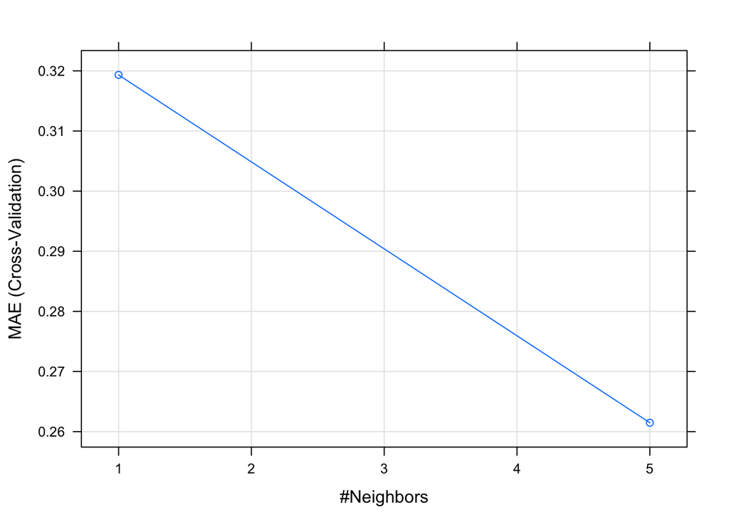

```r
# Examine results
plot(knn_model_3)
```

```r
knn_model_3$bestTune
```

```
##   k
## 2 5
```

```r
knn_model_3$results %>%
  filter(k == knn_model_3$bestTune$k)
```

```
##   k      RMSE  Rsquared       MAE    RMSESD RsquaredSD      MAESD
## 1 5 0.6387762 0.3526001 0.2614734 0.2064368  0.1320186 0.02394247
```

```r
knn_model_3
```

```
## k-Nearest Neighbors
##
## 5000 samples
##   22 predictor
##
## Pre-processing: centered (61), scaled (61)
## Resampling: Cross-Validated (10 fold)
## Summary of sample sizes: 4500, 4500, 4500, 4501, 4498, 4501, ...
## Resampling results across tuning parameters:
##
##   k  RMSE       Rsquared   MAE
##   1  0.7416528  0.2535878  0.3193247
##   5  0.6387762  0.3526001  0.2614734
##
## MAE was used to select the optimal model using the smallest value.
## The final value used for the model was k = 5.
```

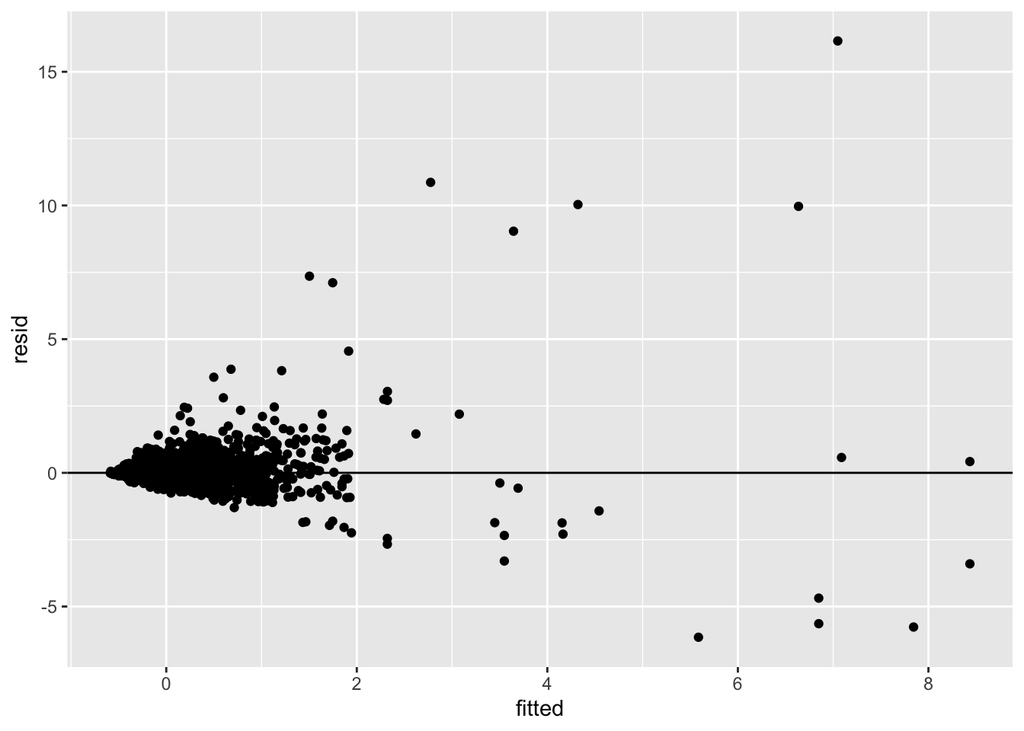

```r
result_knn <- data.frame(resid = resid(knn_model_3), fitted = fitted(knn_model_3))
# Residual plot
ggplot(result_knn, aes(x = fitted, y = resid)) +
  geom_point() +
  geom_hline(yintercept = 0)
```

## Part 3: Summarize

Studying the relationship between price and square feet:

Many of the predictors left in our model like “neighbourhood_groupManhattan” are cateogrical variables and have smaller coefficients than square feet which means their effect is dwarfed compared to square feet.

It makes sense that square feet and price have a strong and positive correlation with each other. Especially in New York City, the main factor that determines the value of a property is the amount of space. Since we are only comparing listings that are all within New York, location doesn’t have as large of an effect as square feet which is why the only location oriented variable not ommited in our model is “neighbourhood_groupManhattan”. If we had listings from both rural Minnesota and downtown New York, then we can imagine location being a much stronger predictor of price.

We can focus on two listings in the data set (id # 738588 & 259946) to see how square feet affects prices. The first has a price of $625 with a square footage of 3700 and the second listing is listed at 125 with a sqaure footage of 700. From comparing these two, we see that price and square footage are strongly and positively correlated with each other.